# knn_classifier

```python
import numpy as np
import pandas as pd
import matplotlib.pyplot as plt
import seaborn as sns

from sklearn.model_selection import train_test_split
from sklearn.neighbors import KNeighborsClassifier
from sklearn.metrics import confusion_matrix, classification_report, roc_auc_score, average_precision_score, log_loss
from sklearn.preprocessing import OneHotEncoder

from dataset import Spec, fit_encoders
from trainer import compute_metrics
from knn import KNNSpec, KNNConfig, evaluate_knn_cv, plot_cv_metric_vs_k, eval_and_plot_confusion, _build_fold_matrices

df = pd.read_csv('/home/losmi/docs/docs/processed.csv')

num_cols=['Age', 'ALB', 'ALT', 'BIL', 'CHE', 'CHOL', 'CREA', 'GGT', 'PROT']
cat_cols=['is_male']
target_col='class'
drop_cols=['Unnamed: 0', 'Sex', 'Category', 'Category_norm']

spec = KNNSpec(num_cols, cat_cols, target_col, drop_cols)
```

### Classes

In order to properly create `KNN` classifier, we have created `KNNSpec` and `KNNConfig` helper classes, which represent dataset and architecture hyperparameter specification. Using these two classes, the function `evaluate_knn_cnn` performs evaluation of different classificator configurations over a specified grid, performs comparison over the validation set, and picks the best configuration based on the specified metric which is then evaluated on the test set. Likewise, using `Encoders` class we perform data normalization using training set metrics. Specifically:

$$z_i = \dfrac{x_i - \mu_{\text{train}}}{\sigma_{\text{train}}}$$

$$\mu_{\text{train}} = \dfrac{1}{N_{\text{train}}} \sum_{j=1}^{N_{\text{train}}} x_j$$

$$\sigma_{\text{train}} = \sqrt{ \dfrac{1}{N_{\text{train}}} \sum_{j=1}^{N_{\text{train}}} (x_j - \mu_{\text{train}})^2 }$$

$$z = \dfrac{x - \mu_{\text{train}}}{\sigma_{\text{train}}}$$

```python
y_all = df[target_col].to_numpy(np.int8)
idx_tr, idx_te = train_test_split(
    np.arange(len(df)), test_size=0.1, stratify=y_all, random_state=42
)
df_tr = df.iloc[idx_tr].reset_index(drop=True)
df_te = df.iloc[idx_te].reset_index(drop=True)
```

We are performing stratified splitting of the data into balanced classes across the different splits. We split the dataset $9:1$.

```python
df_tr.head()
```

|  | Unnamed: 0 | Category | Age | Sex | ALB | ALP | ALT | AST | BIL | CHE | CHOL | CREA | GGT | PROT | is_male | category_norm | class |
| --- | --- | --- | --- | --- | --- | --- | --- | --- | --- | --- | --- | --- | --- | --- | --- | --- | --- |
| 0 | 145 | 0=Blood Donor | 45 | m | 44.3 | 71.5 | 15.9 | 16.3 | 7.3 | 8.00 | 5.35 | 83.0 | 19.8 | 71.3 | 1 | blood_donor | 0 |
| 1 | 531 | 0=Blood Donor | 68 | f | 41.4 | 102.3 | 38.4 | 26.4 | 6.8 | 8.50 | 6.79 | 59.0 | 23.8 | 68.9 | 0 | blood_donor | 0 |
| 2 | 39 | 0=Blood Donor | 35 | m | 44.5 | 70.3 | 26.2 | 25.1 | 5.1 | 10.12 | 4.69 | 82.0 | 20.7 | 67.2 | 1 | blood_donor | 0 |
| 3 | 110 | 0=Blood Donor | 42 | m | 37.8 | 78.6 | 51.4 | 31.8 | 10.1 | 9.66 | 6.15 | 85.0 | 15.1 | 70.8 | 1 | blood_donor | 0 |
| 4 | 150 | 0=Blood Donor | 46 | m | 37.9 | 79.9 | 17.7 | 20.1 | 12.7 | 10.10 | 5.38 | 72.0 | 12.7 | 67.7 | 1 | blood_donor | 0 |

## Classifier Evaluation

The classifier was evaluated using *k-fold cross-validation*. The input dataset was divided into *k subsets*. We train the classifier on *k−1 subsets* and evaluate it on the remaining one.

This procedure is repeated for every possible choice of the held-out subset. The overall complexity is *O(k × α)*, where *O(α)* is the cost of fitting and evaluating the classifier for a single subset.

```python
cfg = KNNConfig(
    seed=42, p=2, n_jobs=None
)

cv = evaluate_knn_cv(df_tr, spec, cfg, n_splits=20, shuffle=True)
grid_folds = cv['grid_folds']
grid_agg = cv['grid_agg']
best = cv['best']

display(grid_agg.head(10))
print('best:', best)
```

|  | k | weights | acc_mean | acc_std | f1_mean | f1_std | auroc_mean | auroc_std | auprc_mean | auprc_std | logloss_mean | logloss_std | recall_mean | recall_std |
| --- | --- | --- | --- | --- | --- | --- | --- | --- | --- | --- | --- | --- | --- | --- |
| 0 | 3 | distance | 0.939749 | 0.029479 | 0.643571 | 0.232122 | 0.858507 | 0.137095 | 0.747404 | 0.236146 | 1.242704 | 1.124745 | 0.520833 | 0.241636 |
| 1 | 3 | uniform | 0.939749 | 0.029479 | 0.643571 | 0.232122 | 0.857552 | 0.137978 | 0.722533 | 0.241456 | 1.243870 | 1.125274 | 0.520833 | 0.241636 |
| 2 | 1 | distance | 0.930622 | 0.035409 | 0.665000 | 0.174287 | 0.779167 | 0.096636 | 0.544874 | 0.204919 | 2.500648 | 1.276257 | 0.579167 | 0.184318 |
| 3 | 1 | uniform | 0.930622 | 0.035409 | 0.665000 | 0.174287 | 0.779167 | 0.096636 | 0.544874 | 0.204919 | 2.500648 | 1.276257 | 0.579167 | 0.184318 |
| 4 | 5 | distance | 0.930622 | 0.026004 | 0.574524 | 0.243371 | 0.880642 | 0.119853 | 0.786587 | 0.197463 | 0.942762 | 0.880885 | 0.445833 | 0.221760 |
| 5 | 5 | uniform | 0.926918 | 0.026427 | 0.534524 | 0.268779 | 0.878559 | 0.119564 | 0.731379 | 0.207159 | 0.946100 | 0.880068 | 0.412500 | 0.236438 |
| 6 | 7 | distance | 0.923280 | 0.028661 | 0.487857 | 0.290003 | 0.897569 | 0.127148 | 0.806640 | 0.208582 | 0.768901 | 0.898762 | 0.366667 | 0.245426 |
| 7 | 7 | uniform | 0.923280 | 0.028661 | 0.487857 | 0.290003 | 0.892882 | 0.128139 | 0.746258 | 0.239541 | 0.774777 | 0.899148 | 0.366667 | 0.245426 |
| 8 | 9 | distance | 0.921495 | 0.024221 | 0.488333 | 0.246917 | 0.892014 | 0.130217 | 0.796521 | 0.214598 | 0.785255 | 0.892225 | 0.354167 | 0.203900 |
| 9 | 9 | uniform | 0.921495 | 0.024221 | 0.488333 | 0.246917 | 0.886806 | 0.129144 | 0.742079 | 0.218755 | 0.793448 | 0.891159 | 0.354167 | 0.203900 |

```
best: {'k': 3, 'weights': 'distance', 'acc_mean': 0.9397486772486772, 'acc_std': 0.029479304361422706, 'f1_mean': 0.6435714285714286, 'f1_std': 0.23212193852154597, 'auroc_mean': 0.8585069444444444, 'auroc_std': 0.13709493376413087, 'auprc_mean': 0.7474041005291004, 'auprc_std': 0.23614568076696793,…
```

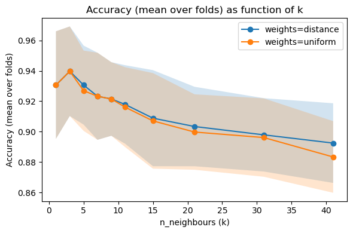

```python
_ = plot_cv_metric_vs_k(grid_agg, metric='acc_mean')
plt.show()
```

## Result Analysis

We observe that the **accuracy** decreases as the number of neighbors increases beyond the optimal value of **3**. This behavior is expected given the distribution of the input dataset. Specifically, when the ratio of labels is approximately **7:1**, the KNN classifier is not an ideal classification method because the labels are unevenly distributed in the feature space.

```python
spec_ds = Spec(spec.num_cols, spec.cat_cols, spec.target_col, drop_cols=spec.drop_cols)
enc = fit_encoders(df_tr, spec_ds)
```

```python
X_tr, y_tr, X_te, y_te = _build_fold_matrices(df, spec, idx_tr, idx_te, cfg.onehot_threshold)

best_k = int(best['k'])
best_w = best['weights']
knn = KNeighborsClassifier(best_k, weights=best_w, p=cfg.p, n_jobs=cfg.n_jobs)
knn.fit(X_tr, y_tr)
```

```
KNeighborsClassifier(n_neighbors=3, weights='distance')
```

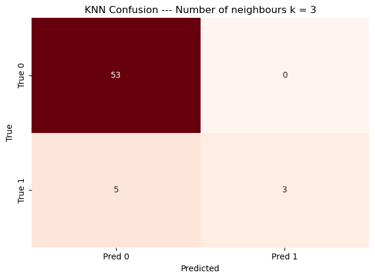

```
{'acc': 0.9180327868852459,
 'f1': 0.5454545454545454,
 'auroc': 0.7334905660377358,
 'auprc': 0.5405737704918032,
 'logloss': 2.4128920796115465,
 'precision': 1.0,
 'recall': 0.375,
 'fpr': 0.0}
```

```python
eval_and_plot_confusion(knn, X_te, y_te, neigh=best_k)
```